# Practical Machine Learning: Prediction Assignment

Brooke

Thursday, June 11, 2015

### Background

Using devices such as Jawbone Up, Nike FuelBand, and Fitbit it is now possible to collect a large amount of data about personal activity relatively inexpensively. These type of devices are part of the quantified self movement - a group of enthusiasts who take measurements about themselves regularly to improve their health, to find patterns in their behavior, or because they are tech geeks. One thing that people regularly do is quantify how much of a particular activity they do, but they rarely quantify how well they do it. In this project, your goal will be to use data from accelerometers on the belt, forearm, arm, and dumbell of 6 participants. They were asked to perform barbell lifts correctly and incorrectly in 5 different ways. More information is available from the website [here](http://groupware.les.inf.puc-rio.br/har) (see the section on the Weight Lifting Exercise Dataset).

### Data

The training data for this project are available here:

https://d396qusza40orc.cloudfront.net/predmachlearn/pml-training.csv

The test data are available here:

https://d396qusza40orc.cloudfront.net/predmachlearn/pml-testing.csv

The data for this project come from [Groupware@LES](http://groupware.les.inf.puc-rio.br/har).

### Objectives:

The goal of this project is to predict the manner in which the subjects did the exercise (**“classe”** variable in the training set).

### Reading & Cleaning Data

```r
train<-read.csv("https://d396qusza40orc.cloudfront.net/predmachlearn/pml-training.csv", na.strings=c("NA","#DIV/0!", ""))
test<-read.csv("https://d396qusza40orc.cloudfront.net/predmachlearn/pml-testing.csv", na.strings=c("NA","#DIV/0!", ""))
```

To clean the data, we will need to determine columns/variables to be removed: “bookkeeping columns”, zero covariates, and NA values.

**Step 1: Finding “bookkeeping columns”** (look at the first 15 column names):

```r
names(train)[1:15]
```

```
##  [1] "X"                    "user_name"            "raw_timestamp_part_1"
##  [4] "raw_timestamp_part_2" "cvtd_timestamp"       "new_window"
##  [7] "num_window"           "roll_belt"            "pitch_belt"
## [10] "yaw_belt"             "total_accel_belt"     "kurtosis_roll_belt"
## [13] "kurtosis_picth_belt"  "kurtosis_yaw_belt"    "skewness_roll_belt"
```

Columns 1-7 are the “bookkeeping columns” (user name, time stamps, window number, etc). They will not be helpful in building our prediction model.

**Step 2: Find zero covariates**:

We will use the function **nearZeroVar()** from the **caret** package. **saveMetrics=FALSE** (default setting) conveniently returns the positions of zero or near zero variance predictors.

```r
library(caret)
nearZeroVar(train)
```

```
##  [1]   6  14  17  26  51  52  53  54  55  56  57  58  59  75  78  79  81
## [18]  82  89  92 101 127 130 131 134 137 139 142 143 144 145 146 147 148
## [35] 149 150
```

We will now remove all columns we have found above:

```r
index<-c(1:7, 14,17,26, 51:59, 75, 78, 79, 81, 82, 89, 92, 101, 127, 130, 131, 134, 137, 139, 142:150 )
Train<-train[, -index]
```

**Step 3: NA values**

Now let’s find out the rate of NAs in the remaining columns:

```r
naRate<-colSums(is.na(Train))/nrow(Train)
```

Please refer to Appendix (Table 1) to see NA rates. We can see that NA rate is either 0% (i.e., those predictors have no missing values) or 97-98% (i.e., those columns are mostly comprised of missing values). Naturally, we will keep the predictors with 0% NAs and remove the ones with 97-98% NAs.

```r
Index<-which(naRate==0.00)
Train<-Train[, Index]
```

Check to make sure there are no missing values in the remaining predictors:

```r
colSums(is.na(Train)) # no missing values
```

```r
dim(Train)
```

```
## [1] 19622    53
```

Our clean Train dataset has 53 variables: 52 predictors and one outcome variable, **classe** (please see Table 2 in Appendix). Before we proceed with the model training, we will clean the test set in the same exact manner we did the train set. Note that the test set has an extra variable **problem_id**, which we will remove as well (not a predictor – another “bookkeeping column”):

```r
Test<-test[, -index]
Test<-Test[, Index]
str(Test$problem_id) # making sure the variable is not of value
```

```
##  int [1:20] 1 2 3 4 5 6 7 8 9 10 ...
```

```r
Test<-Test[, -53] # removing column problem_id
dim(Test)
```

```
## [1] 20 52
```

The test set now has the same 52 predictors as the training set (please see table 3 in Appendix). The last step in cleaning/preparing the data will be to “factorise” outcome variable **classe** in the Train set:

```r
Train$classe<-as.factor(Train$classe)
```

### Prediction Model

In order to estimate the test error (that is, the error when we apply the prediction model to the data that was not used to train the model, also known as out of sample error) and ultimately, determine how well a statistical learning method that we choose can be expected to perform on independent data, we need to perform cross validation. To do so, we will use the the validation set approach and split the clean training set into sub-training and validation sets, with the help of the **createDataPartition()** function from the **caret** package.

**Step 1: Separate the Train data into training (60% of the Train data) and validation (40% of the Train data) sets, and remove the outcome variable from both resulting sets**:

```r
set.seed(357)
inTrain<-createDataPartition(Train$classe, p=0.6, list=FALSE)
training<-Train[inTrain, ]
valid<-Train[-inTrain, ]
data<-training[-53]
newdata<-valid[-53]
```

**Step 2: Fit a model**

We will be predicting with Random Forest, which is one of the most accurate predicting algorithms. In order to speed things up, we will use Parallel Random Forest (which is quite faster than fitting Random Forest, see [this link](http://www.r-bloggers.com/introducing-parallelrandomforest-faster-leaner-parallelized/) and [this link](http://cran.r-project.org/web/packages/foreach/vignettes/foreach.pdf) for more details).

We want to create a Random Forest model with a total of 1000 trees. Our computer has 2 cores in it, so we can split the number of trees to be constructed into 2 parts, 500 for each core. **combine** function that comes with **randomForest** package will combine the resulting Random Forest objects into one model.

```r
set.seed(1379)
library(foreach)
library(randomForest)
library(doParallel)
```

```r
RF<-foreach(ntree=rep(500,2), .combine=combine, .packages='randomForest') %dopar% randomForest(data, training$classe, ntree=ntree)
RF
```

```
##
## Call:
##  randomForest(x = data, y = training$classe, ntree = ntree)
##                Type of random forest: classification
##                      Number of trees: 1000
## No. of variables tried at each split: 7
```

Let’s take a look at the plot of important variables in our model:

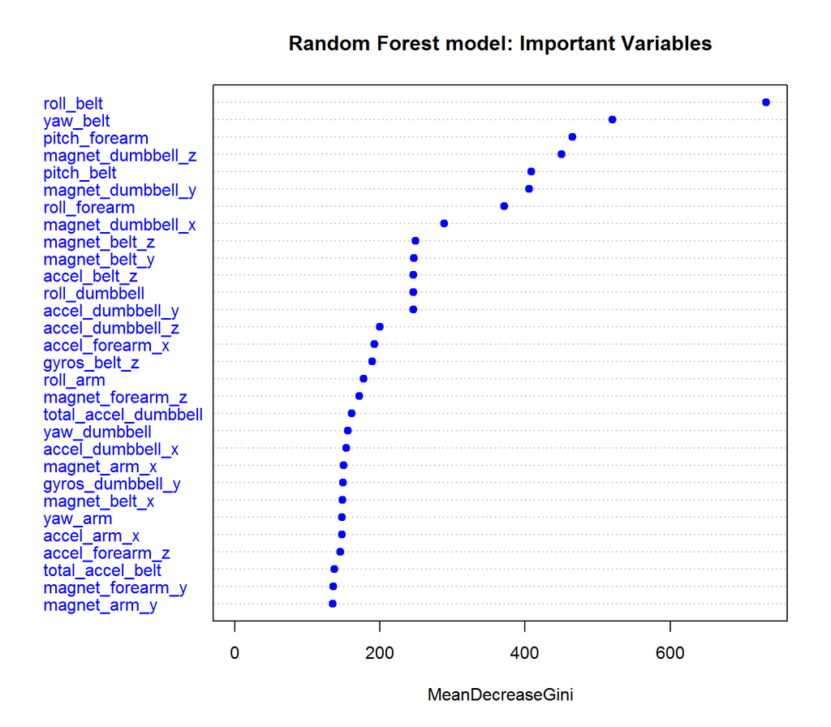

```r
varImpPlot(RF, main="Random Forest model: Important Variables", col="blue", pch=19)
```

Out of a total of 52 predictors, only about 30 were the most important ones to train our prediction model.

**In sample error** (a.k.a. train error):

Since we are using the data on which we trained the model, we expect this model to perform very well on the training dataset, with a high accuracy rate and low error rates:

```r
pred<-predict(RF, data)
cm<-confusionMatrix(pred, training$classe)
cm
```

```
## Confusion Matrix and Statistics
##
##           Reference
## Prediction    A    B    C    D    E
##          A 3348    0    0    0    0
##          B    0 2279    0    0    0
##          C    0    0 2054    0    0
##          D    0    0    0 1930    0
##          E    0    0    0    0 2165
##
## Overall Statistics
##
##                Accuracy : 1
##                  95% CI : (0.9997, 1)
##     No Information Rate : 0.2843
##     P-Value [Acc > NIR] : < 2.2e-16
##
##                   Kappa : 1
##  Mcnemar's Test P-Value : NA
##
## Statistics by Class:
##
##                      Class: A Class: B Class: C Class: D Class: E
## Sensitivity            1.0000   1.0000   1.0000   1.0000   1.0000
## Specificity            1.0000   1.0000   1.0000   1.0000   1.0000
## Pos Pred Value         1.0000   1.0000   1.0000   1.0000   1.0000
## Neg Pred Value         1.0000   1.0000   1.0000   1.0000   1.0000
## Prevalence             0.2843   0.1935   0.1744   0.1639   0.1838
## Detection Rate         0.2843   0.1935   0.1744   0.1639   0.1838
## Detection Prevalence   0.2843   0.1935   0.1744   0.1639   0.1838
## Balanced Accuracy      1.0000   1.0000   1.0000   1.0000   1.0000
```

The **in sample error** is virtually non-existent: the accuracy rate for the training set is 100% – with such high accuracy rate, there is a danger of possibly overfitting the training data. If that is indeed the case, we will expect **out of sample error** to be significantly higher, and the accuracy to be significantly lower. However, even if there is no overfitting, the **out of sample error** will always be higher than **in sample error**.

**Out of Sample Error (a.k.a. test error): Predictions & Confusion Matrix**

```r
predRF<-predict(RF, newdata)
cmRF<-confusionMatrix(predRF, valid$classe)
cmRF
```

```
## Confusion Matrix and Statistics
##
##           Reference
## Prediction    A    B    C    D    E
##          A 2230   13    0    0    0
##          B    2 1499    8    0    0
##          C    0    6 1359   22    0
##          D    0    0    1 1264    3
##          E    0    0    0    0 1439
##
## Overall Statistics
##
##                Accuracy : 0.993
##                  95% CI : (0.9909, 0.9947)
##     No Information Rate : 0.2845
##     P-Value [Acc > NIR] : < 2.2e-16
##
##                   Kappa : 0.9911
##  Mcnemar's Test P-Value : NA
##
## Statistics by Class:
##
##                      Class: A Class: B Class: C Class: D Class: E
## Sensitivity            0.9991   0.9875   0.9934   0.9829   0.9979
## Specificity            0.9977   0.9984   0.9957   0.9994   1.0000
## Pos Pred Value         0.9942   0.9934   0.9798   0.9968   1.0000
## Neg Pred Value         0.9996   0.9970   0.9986   0.9967   0.9995
## Prevalence             0.2845   0.1935   0.1744   0.1639   0.1838
## Detection Rate         0.2842   0.1911   0.1732   0.1611   0.1834
## Detection Prevalence   0.2859   0.1923   0.1768   0.1616   0.1834
## Balanced Accuracy      0.9984   0.9930   0.9945   0.9911   0.9990
```

As expected, the **out of sample error** rates (a.k.a. test error) are higher than the **in sample/train error** rates above, and the accuracy rate is lower. However, the accuracy rate is still very high, and so is Kappa statistic (which indicates how closely the instances classified by the machine learning classifier matched the true results), and error rates for each class seem to be extremely low (see Statistics by Class in the output above):

```
## [1] "Model Accuracy:  0.993"
```

```
## [1] "Kappa Statistic:  0.9911"
```

We can certainly see that the reputation of Random Forest as one of the most accurate prediction algorithms is not unfounded.

**Independent Test set: Predictions**

We will now predict the results for the Test set and see how our machine learning method performs on independent data:

```r
predictions<-predict(RF, Test)
```

Using the code provided by the Coursera instructors, we will prepare the files with the answers:

```r
 pml_write_files = function(x){
+     n = length(x)
+     for(i in 1:n){
+         filename = paste0("problem_id_",i,".txt")
+         write.table(x[i],file=filename,quote=FALSE,row.names=FALSE,col.names=FALSE)
+     }
+ }

pml_write_files(predictions)
```

These results have been submitted and deemed correct (with 100% accuracy), which supports the high accuracy rate of our model.

#### Appendix

**Table 1: NA Rates**:

```r
naRate
```

```
##                roll_belt               pitch_belt                 yaw_belt
##                0.0000000                0.0000000                0.0000000
##         total_accel_belt       kurtosis_roll_belt      kurtosis_picth_belt
##                0.0000000                0.9798186                0.9809398
##       skewness_roll_belt     skewness_roll_belt.1            max_roll_belt
##                0.9797676                0.9809398                0.9793089
##           max_picth_belt             max_yaw_belt            min_roll_belt
##                0.9793089                0.9798186                0.9793089
##           min_pitch_belt             min_yaw_belt      amplitude_roll_belt
##                0.9793089                0.9798186                0.9793089
##     amplitude_pitch_belt     var_total_accel_belt            avg_roll_belt
##                0.9793089                0.9793089                0.9793089
##         stddev_roll_belt            var_roll_belt           avg_pitch_belt
##                0.9793089                0.9793089                0.9793089
##        stddev_pitch_belt           var_pitch_belt             avg_yaw_belt
##                0.9793089                0.9793089                0.9793089
##          stddev_yaw_belt             var_yaw_belt             gyros_belt_x
##                0.9793089                0.9793089                0.0000000
##             gyros_belt_y             gyros_belt_z             accel_belt_x
##                0.0000000                0.0000000                0.0000000
##             accel_belt_y             accel_belt_z            magnet_belt_x
##                0.0000000                0.0000000                0.0000000
##            magnet_belt_y            magnet_belt_z                 roll_arm
##                0.0000000                0.0000000                0.0000000
##                pitch_arm                  yaw_arm          total_accel_arm
##                0.0000000                0.0000000                0.0000000
##            var_accel_arm              gyros_arm_x              gyros_arm_y
##                0.9793089                0.0000000                0.0000000
##              gyros_arm_z              accel_arm_x              accel_arm_y
##                0.0000000                0.0000000                0.0000000
##              accel_arm_z             magnet_arm_x             magnet_arm_y
##                0.0000000                0.0000000                0.0000000
##             magnet_arm_z        kurtosis_roll_arm       kurtosis_picth_arm
##                0.0000000                0.9832841                0.9833860
##         kurtosis_yaw_arm        skewness_roll_arm       skewness_pitch_arm
##                0.9798695                0.9832331                0.9833860
##         skewness_yaw_arm            max_picth_arm              max_yaw_arm
##                0.9798695                0.9793089                0.9793089
##              min_yaw_arm        amplitude_yaw_arm            roll_dumbbell
##                0.9793089                0.9793089                0.0000000
```

[output cut: 25 more lines]

```
##                0.0000000                0.9835898                0.9836408
##    skewness_roll_forearm   skewness_pitch_forearm        max_picth_forearm
##                0.9835389                0.9836408                0.9793089
##          max_yaw_forearm        min_pitch_forearm          min_yaw_forearm
##                0.9835898                0.9793089                0.9835898
##  amplitude_pitch_forearm      total_accel_forearm        var_accel_forearm
##                0.9793089                0.0000000                0.9793089
##          gyros_forearm_x          gyros_forearm_y          gyros_forearm_z
##                0.0000000                0.0000000                0.0000000
##          accel_forearm_x          accel_forearm_y          accel_forearm_z
##                0.0000000                0.0000000                0.0000000
##         magnet_forearm_x         magnet_forearm_y         magnet_forearm_z
##                0.0000000                0.0000000                0.0000000
##                   classe
##                0.0000000
```

**Table 2: Variable Names (Train)**:

```r
names(Train)
```

```
##  [1] "roll_belt"            "pitch_belt"           "yaw_belt"
##  [4] "total_accel_belt"     "gyros_belt_x"         "gyros_belt_y"
##  [7] "gyros_belt_z"         "accel_belt_x"         "accel_belt_y"
## [10] "accel_belt_z"         "magnet_belt_x"        "magnet_belt_y"
## [13] "magnet_belt_z"        "roll_arm"             "pitch_arm"
## [16] "yaw_arm"              "total_accel_arm"      "gyros_arm_x"
## [19] "gyros_arm_y"          "gyros_arm_z"          "accel_arm_x"
## [22] "accel_arm_y"          "accel_arm_z"          "magnet_arm_x"
## [25] "magnet_arm_y"         "magnet_arm_z"         "roll_dumbbell"
## [28] "pitch_dumbbell"       "yaw_dumbbell"         "total_accel_dumbbell"
## [31] "gyros_dumbbell_x"     "gyros_dumbbell_y"     "gyros_dumbbell_z"
## [34] "accel_dumbbell_x"     "accel_dumbbell_y"     "accel_dumbbell_z"
## [37] "magnet_dumbbell_x"    "magnet_dumbbell_y"    "magnet_dumbbell_z"
## [40] "roll_forearm"         "pitch_forearm"        "yaw_forearm"
## [43] "total_accel_forearm"  "gyros_forearm_x"      "gyros_forearm_y"
## [46] "gyros_forearm_z"      "accel_forearm_x"      "accel_forearm_y"
## [49] "accel_forearm_z"      "magnet_forearm_x"     "magnet_forearm_y"
## [52] "magnet_forearm_z"     "classe"
```

**Table 3: Variable Names (Test)**:

```r
names (Test)
```

```
##  [1] "roll_belt"            "pitch_belt"           "yaw_belt"
##  [4] "total_accel_belt"     "gyros_belt_x"         "gyros_belt_y"
##  [7] "gyros_belt_z"         "accel_belt_x"         "accel_belt_y"
## [10] "accel_belt_z"         "magnet_belt_x"        "magnet_belt_y"
## [13] "magnet_belt_z"        "roll_arm"             "pitch_arm"
## [16] "yaw_arm"              "total_accel_arm"      "gyros_arm_x"
## [19] "gyros_arm_y"          "gyros_arm_z"          "accel_arm_x"
## [22] "accel_arm_y"          "accel_arm_z"          "magnet_arm_x"
## [25] "magnet_arm_y"         "magnet_arm_z"         "roll_dumbbell"
## [28] "pitch_dumbbell"       "yaw_dumbbell"         "total_accel_dumbbell"
## [31] "gyros_dumbbell_x"     "gyros_dumbbell_y"     "gyros_dumbbell_z"
## [34] "accel_dumbbell_x"     "accel_dumbbell_y"     "accel_dumbbell_z"
## [37] "magnet_dumbbell_x"    "magnet_dumbbell_y"    "magnet_dumbbell_z"
## [40] "roll_forearm"         "pitch_forearm"        "yaw_forearm"
## [43] "total_accel_forearm"  "gyros_forearm_x"      "gyros_forearm_y"
## [46] "gyros_forearm_z"      "accel_forearm_x"      "accel_forearm_y"
## [49] "accel_forearm_z"      "magnet_forearm_x"     "magnet_forearm_y"
## [52] "magnet_forearm_z"
```